# Analysis of MG63.3 YBX1 GUC6 FLAG data

This document details the analysis of proteomics data acquired to compare MG63.3 GUC6 expressing FLAG tagged versions of YB-1 for interactomics. The raw MS data were compiled to peptide identifications using ProteomeDiscoverer.

## Setting up the environment

These are packages you will need for this notebook. For exact versions used, please refer to the session info at the bottom of this notebook.

```r
library('tidyverse')
library('ggplot2')
library('RColorBrewer')
library('vroom')
library('pheatmap')
library('ggrepel')
```

I want to set a base directory that we can use as a link to the directory where we will do most of the work. I use two directories here because the Workspace is what is pushed to GitHub and contains scripts and plot files, but the Repository is where more of the big data is stored that does not get pushed.

```r
generalDatasets = 'C:/Users/chughes/Documents/bccrc/projectsRepository/generalDatasets'
baseWorkspace = 'C:/Users/chughes/Documents/bccrc/projectsWorkspace/sorensenLab/relatedToYbx1'
baseRepository = 'C:/Users/chughes/Documents/bccrc/projectsRepository/sorensenLab/relatedToYbx1'
#generalDatasets = 'C:/Users/chris/OneDrive/Documents/bccrc/projectsRepository/generalDatasets'
#baseWorkspace = 'C:/Users/chris/OneDrive/Documents/bccrc/projectsWorkspace/sorensenLab/relatedToYbx1'
#baseRepository = 'C:/Users/chris/OneDrive/Documents/bccrc/projectsRepository/sorensenLab/relatedToYbx1'
```

## Data processing

Read the protein annotation details.

```r
##########################################################################################
proteinAnnotation = readRDS(paste(baseRepository, '/proteomics20200705_mg633CrisprYbx1GucClones/uniprotHumanJul2020.fasta.annotated.rds', sep = ''))
```

I will first make a result table for export. First step of this is to parse the data.

```r
##########################################################################################
psm = vroom(paste(baseRepository, '/proteomics20201023_mg633Ybx1Guc6Interaction/ch_20201022_mg633Ybx1Guc6FlagIpSet_TMT16_PSMs.txt', sep = '')) %>%
  dplyr::select(`Protein Accessions`, `Abundance 126`:`Abundance 130N`, `Abundance 133N`:`Abundance 134N`) %>%
  mutate(accession = sapply(str_split(`Protein Accessions`, ';'), '[', 1)) %>%
  dplyr::select(accession, `Abundance 126`:`Abundance 134N`) %>%
  left_join(proteinAnnotation) %>%
  dplyr::select(accession, gene, `Abundance 126`:`Abundance 134N`) %>%
  filter(!grepl('^sp$', accession) | !is.na(gene)) %>%
  mutate(gene = gsub('-', NA, gene, fixed = TRUE)) %>%
  mutate(psms = 1)
```

```
Rows: 3,283
Columns: 53
chr [11]: Confidence, Identifying Node, PSM Ambiguity, Annotated Sequence, Modifications, Master Protein Accessions, Protein Accessions, Activation Type, MS Order, Spectrum File, ...
dbl [40]: PSMs Workflow ID, PSMs Peptide ID, Number of Proteins, Number of Missed Cleavages, Charge, Delta Score, Delta Cn, Rank, Search Engine Rank, mz in Da, MHplus in Da, Theo ...
lgl [ 2]: Checked, Quan Info

Pass a specification to the `col_types` argument to quiet this message
```

Filter the data to remove less confident PSMs.

```r
##########################################################################################
psmFiltered1 = subset(psm, rowSums(is.na(psm[,3:10])) < 6)
psmFiltered2 = subset(psmFiltered1, rowSums(psmFiltered1[,3:10], na.rm = TRUE) > 40)
colnames(psmFiltered2)[3:13] = c('nYb1_1','cYb1_1','nYb1_2','cYb1_2','nYb1_3','cYb1_3','nYb1_4','cYb1_4','nGfp_1','nGfp_2','nGfp_3')
```

Roll the data into proteins.

```r
##########################################################################################
proPsms = psmFiltered2 %>%
  group_by(accession, gene) %>%
  summarise(numPsm = sum(psms, na.rm = TRUE))
pro = psmFiltered2 %>%
  group_by(accession, gene) %>%
  summarise(across(.cols = nYb1_1:nGfp_3, .fns = median, na.rm = TRUE)) %>%
  left_join(proPsms) %>%
  left_join(proteinAnnotation) %>%
  filter(!is.na(gene)) %>%
  arrange(-numPsm)
```

Output the processed data to a file.

```r
##########################################################################################
write.table(pro, paste(baseRepository, '/proteomics20201023_mg633Ybx1Guc6Interaction/dataset_yb1FlagInteractionData.csv', sep = ''),
            col.names = TRUE, row.names = FALSE, quote = FALSE, sep = ',')
```

Make a plot of the YB-1 levels to look at the overall IP quality.

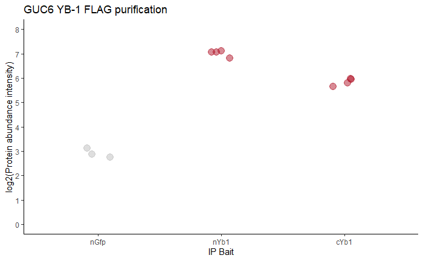

```r
##########################################################################################
goi = ungroup(pro) %>%
  filter(grepl('YBX1', pro$gene)) %>%
  pivot_longer(cols = nYb1_1:nGfp_3, names_to = 'ipName', values_to = 'intensity') %>%
  mutate(ipBait = sub('(.*)_[1-4]', '\\1', ipName)) %>%
  mutate(ipBait = factor(ipBait, levels = c('nGfp','nYb1','cYb1')))
##
ggplot(goi, aes(ipBait, log2(intensity), color = ipBait)) +
  geom_point(size = 4, position = position_jitterdodge(jitter.width = 0.5), alpha = 0.5) +
  labs(x = 'IP Bait', y = 'log2(Protein abundance intensity)', title = 'GUC6 YB-1 FLAG purification') +
  scale_y_continuous(limits = c(0, 8), breaks = seq(0,8,1)) +
  scale_colour_manual(values = c(brewer.pal(8,'Greys')[4], rep(brewer.pal(8,'RdBu')[1],2))) +
  theme_classic() +
  theme(legend.position = 'none')
ggsave(paste(baseRepository, '/proteomics20201023_mg633Ybx1Guc6Interaction/scatter_mg633Ybx1Guc6FlagIpEfficiency.pdf', sep = ''),
       height = 4,
       width = 3,
       useDingbats = FALSE)
```

[session information not shown]